# Exploratory data analysis of DSRCT Samples

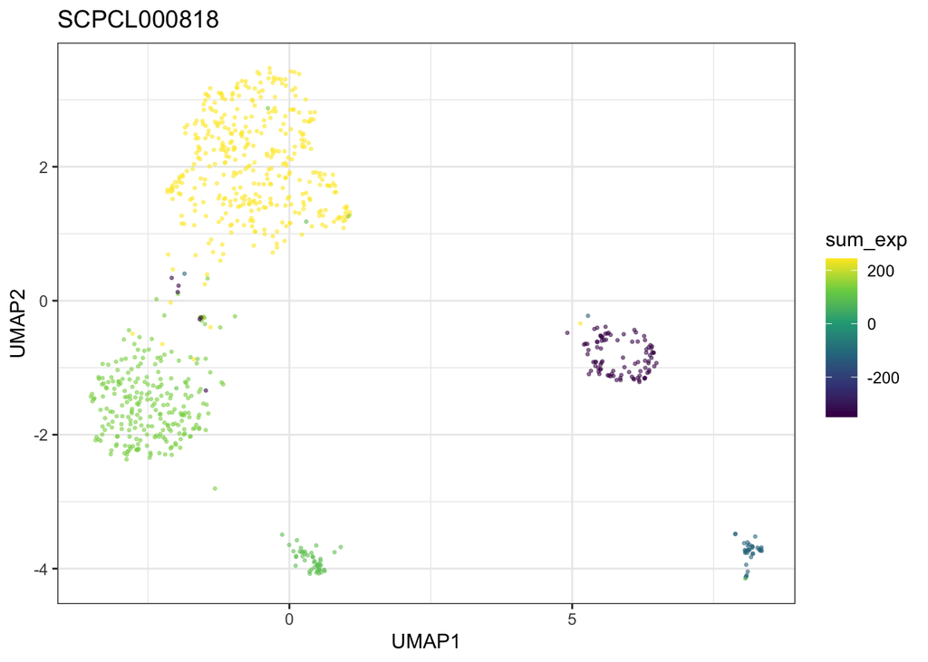

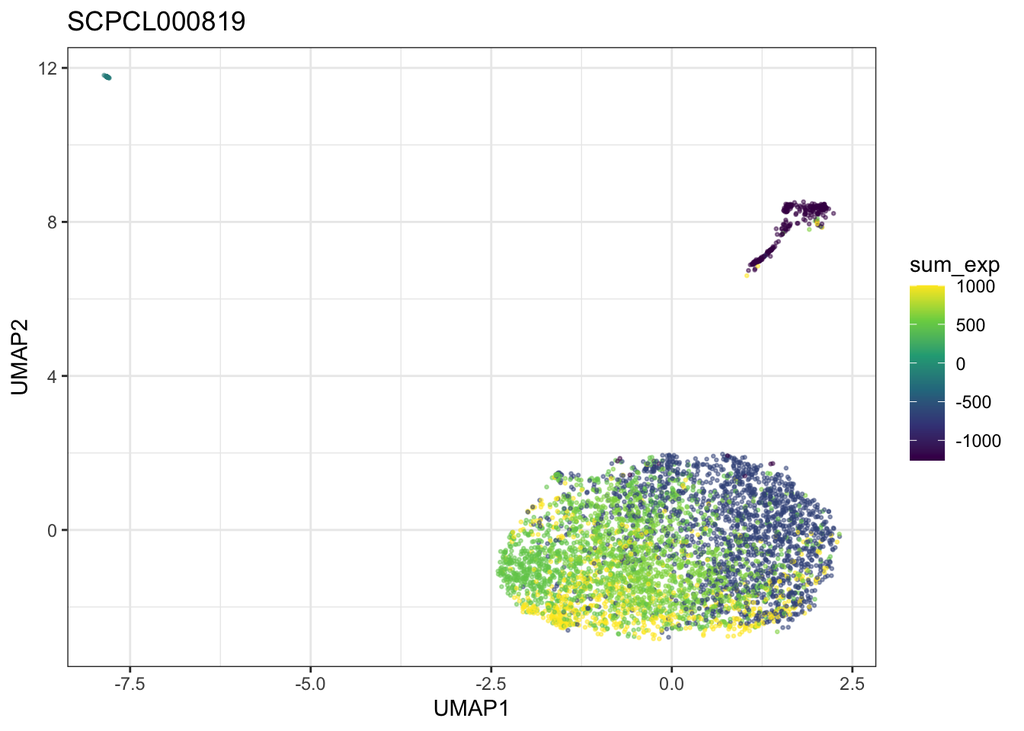

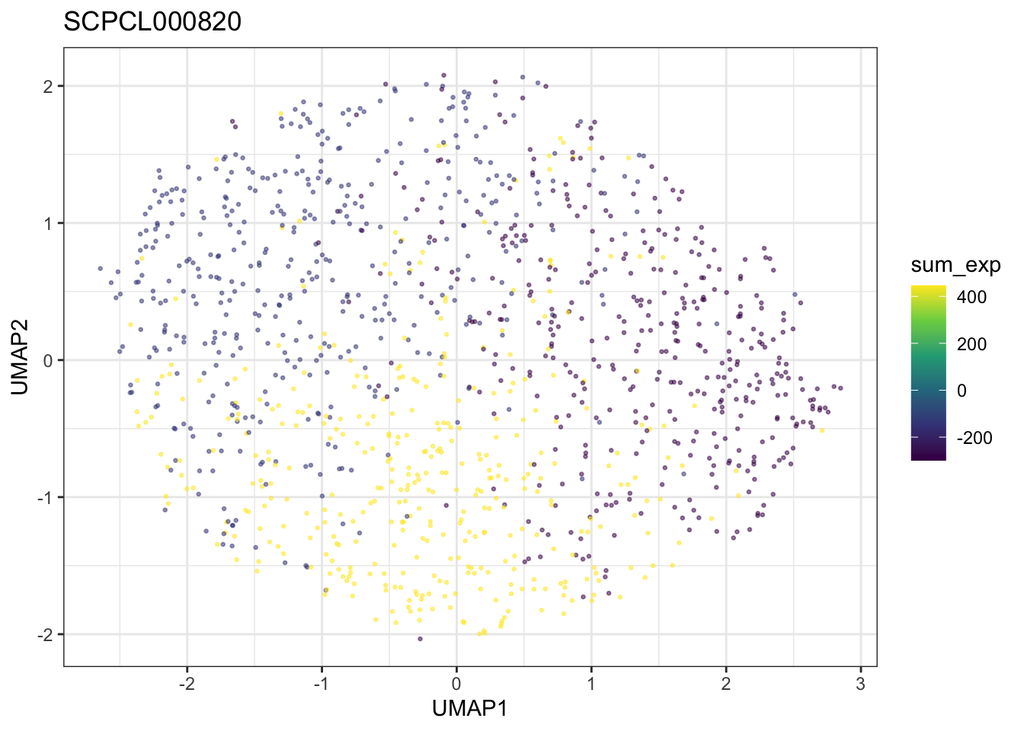

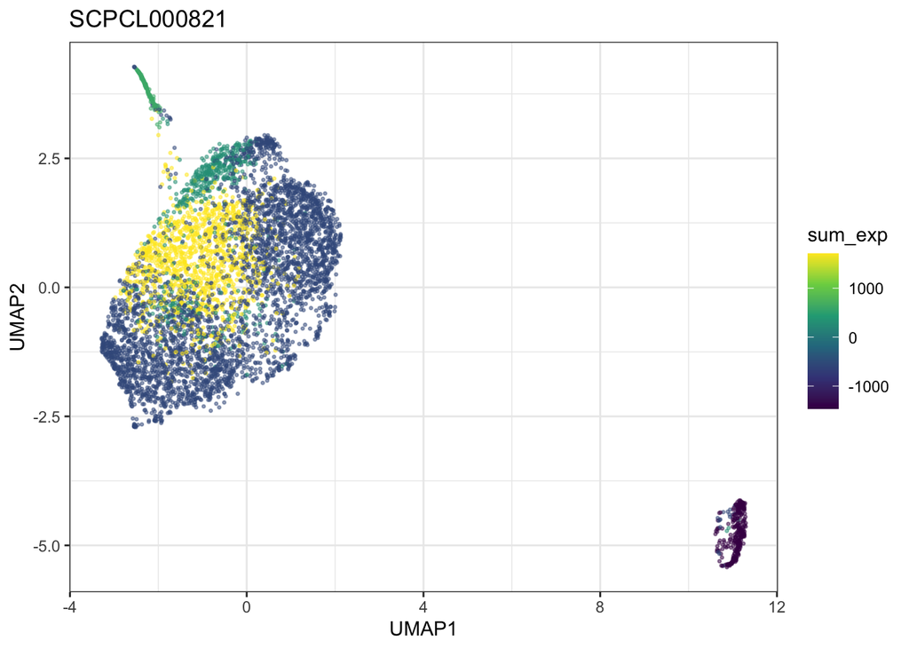

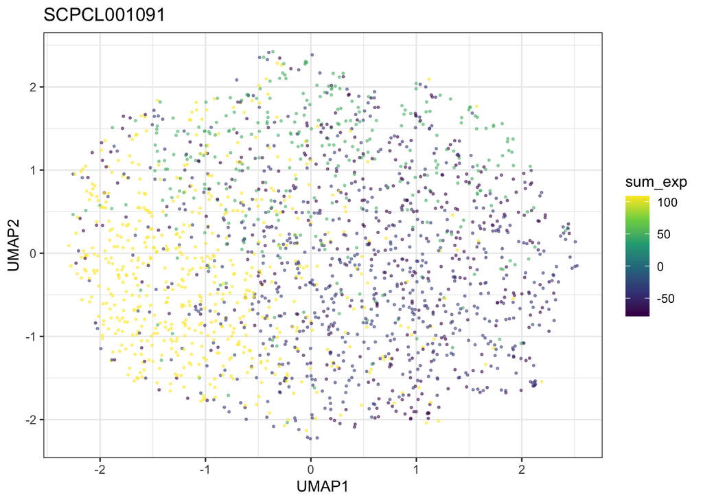

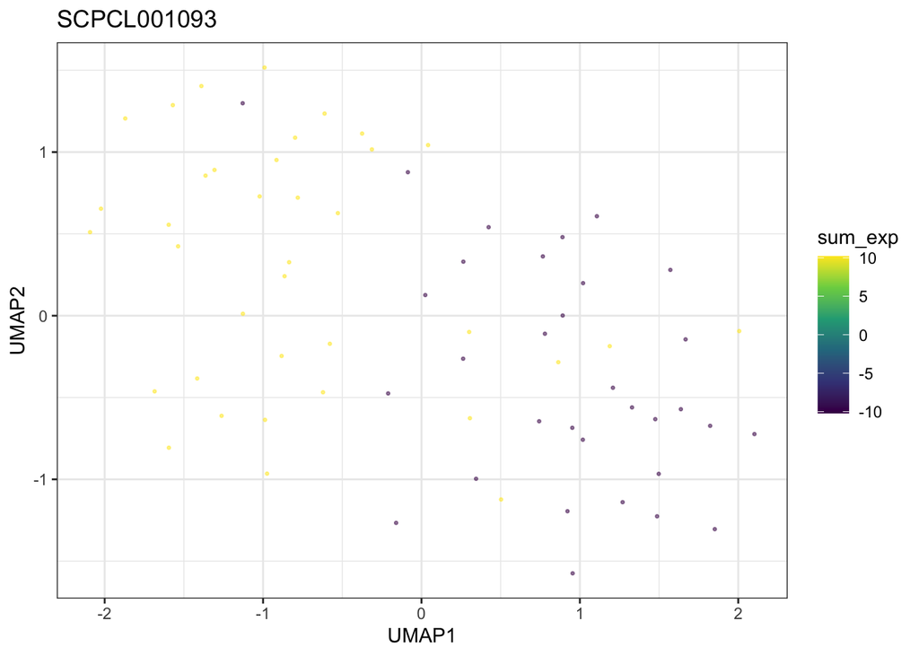

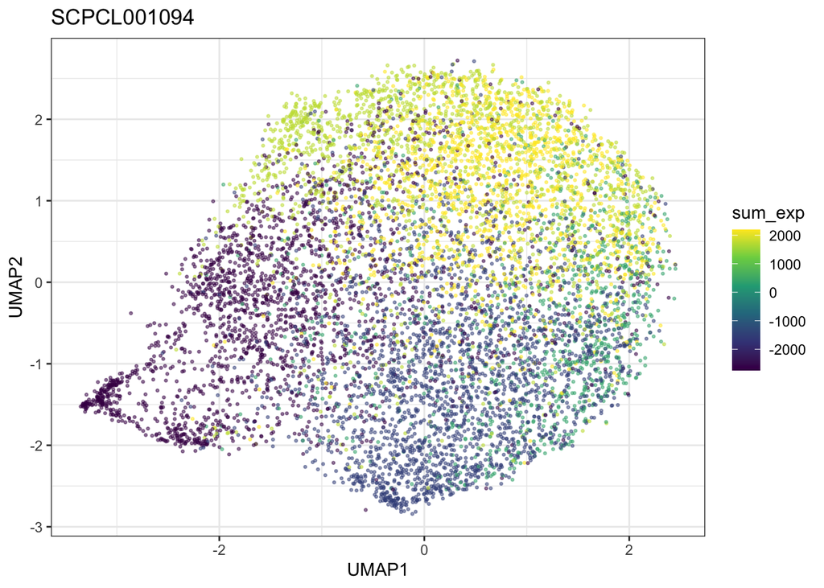

```r
# calculate sum gene expression across all marker genes in list
marker_sum_exp <- lapply(umap_df_list_excluded_scaled, function(x) {
  x |>
    dplyr::group_by(cluster) |> # change to cluster
    dplyr::mutate(sum_exp = sum(transformed_gene_expression, na.rm = T)) |>
    dplyr::select(barcodes, UMAP1, UMAP2, sum_exp, cluster) |>
    dplyr::distinct()
})


# plot mean gene expression

for (i in 1:length(marker_sum_exp)) {
  p <- ggplot(marker_sum_exp[[i]], aes(x = UMAP1, y = UMAP2, color = sum_exp)) +
    geom_point(size = 0.5, alpha = 0.5) +
    scale_color_viridis_c() +
    ggtitle(names(umap_df_list_excluded_scaled)[i])
  print(p)

  # save plots
  ggsave(
    filename = paste0(module_base, "/plots/UMAP_marker_expression_cluster_", names(umap_df_list)[i], ".png"),
    plot = p,
    width = 6,
    height = 6,
    units = "in",
    dpi = 150
  )
}
```

It looks like there are group of cells with high marker gene expression. We anticipate that these are most likely to be the tumor cells. The groups with low or negative values are likely normal cells.

Now let’s classify clusters that has a sum of marker genes > 0 (after z-transformation) as tumor cell clusters.

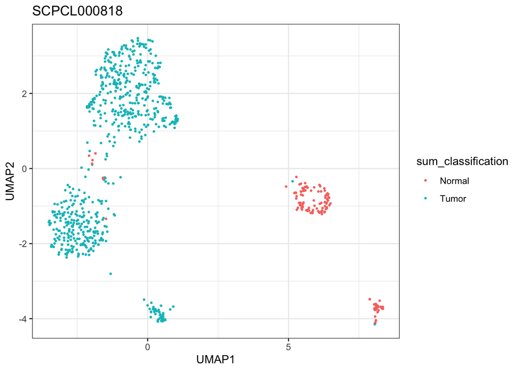

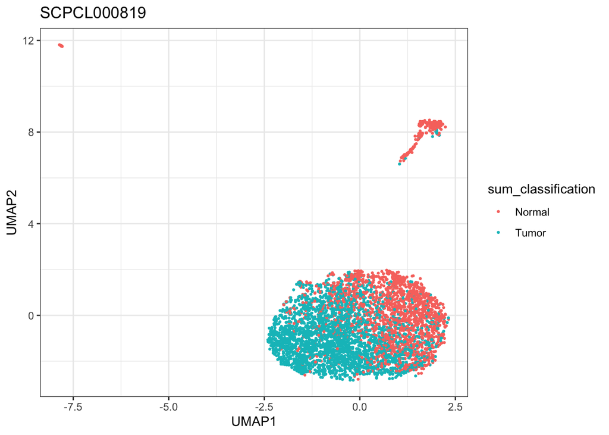

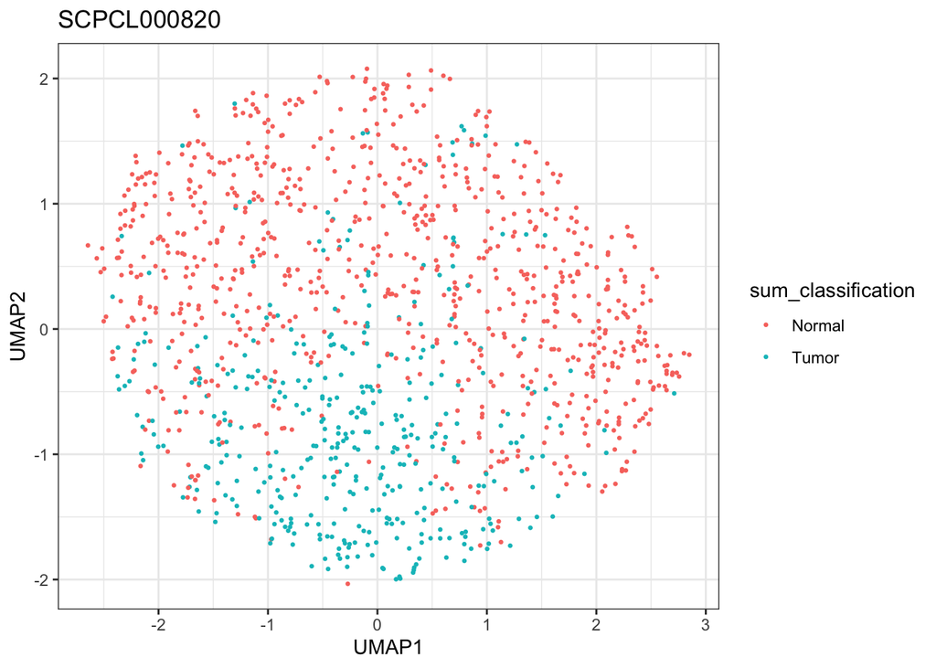

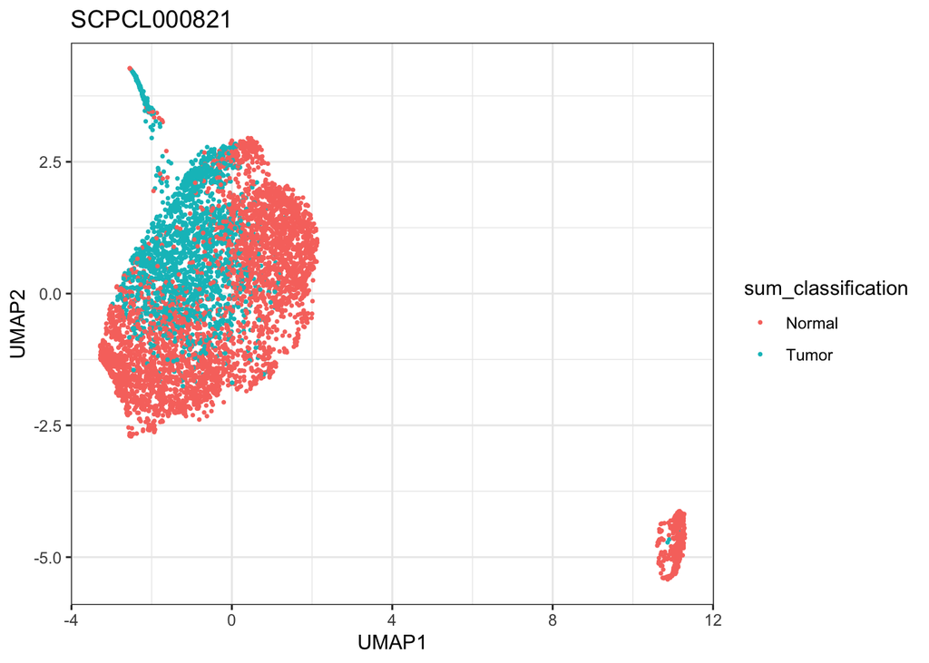

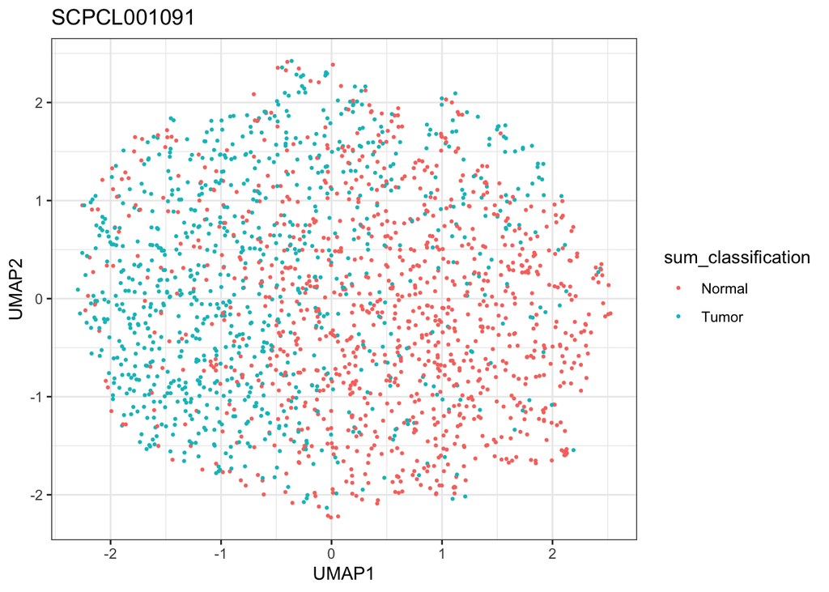

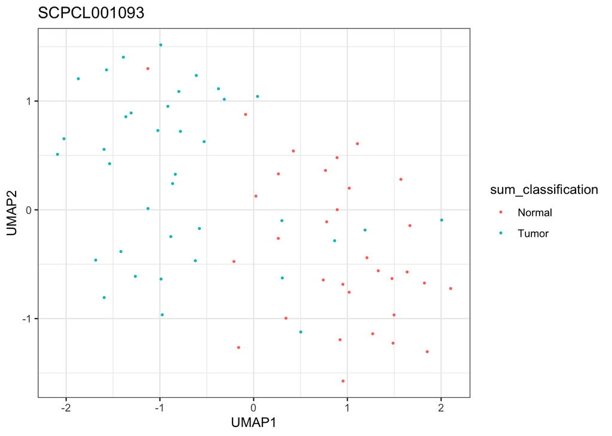

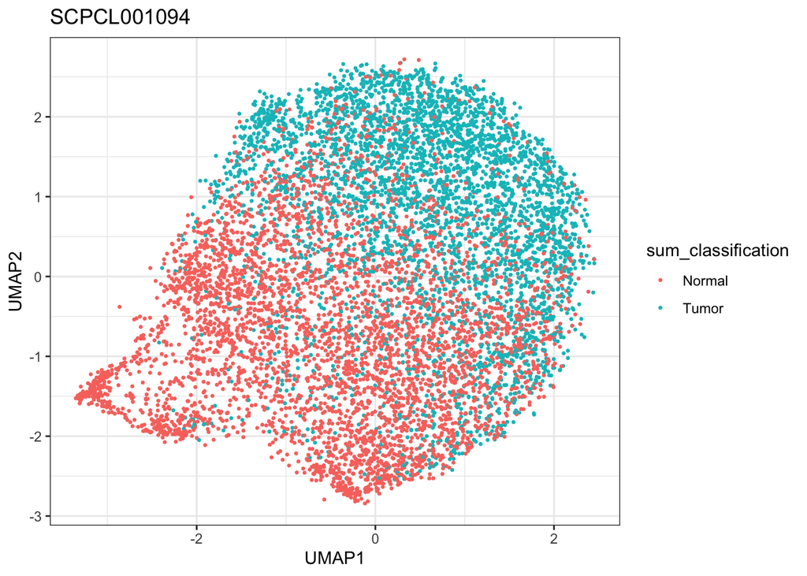

```r
# classify tumor cells based on presence of any marker genes
marker_sum_exp <- lapply(marker_sum_exp, function(x) {
  d <- density(x$sum_exp)

  x |>
    dplyr::mutate(sum_classification = dplyr::if_else(sum_exp > 0, "Tumor", "Normal"))
})


for (i in 1:length(marker_sum_exp)) {
  p <- ggplot(marker_sum_exp[[i]], aes(x = UMAP1, y = UMAP2, color = sum_classification)) +
    geom_point(size = 0.5, alpha = 1) +
    ggtitle(names(umap_df_list_excluded_scaled)[i])
  print(p)

  # save plots
  ggsave(
    filename = paste0(
      module_base,
      "/plots/UMAP_classification_cluster_",
      names(umap_df_list)[i],
      ".png"
    ),
    plot = p,
    width = 6,
    height = 6,
    units = "in",
    dpi = 150
  )
}
```

Based on my experiences, the above plots show that we are unable to adequately determine the tumor cells from the normal cells. This can be seen in SCPCS000729, which is most likely all tumor cells, since it is collected from a patient-derived xenograft.

## Conclusions

- We do see variation in DSRCT-specific gene expression across cells, suggesting that there may be gene drop-out reducing the quality of the data.
- `ST6GALNAC5`, `PTRPQ`, and `IQCJ-SCHIP1` are good markers for the DSRCT cells within this data. The other markers are not as highly expressed either due to heterogeneity or data quality.
- For the next steps, we may try to use `SingleR` or `CellAssign` to identify the normal cells and then work to identify remaining cells as tumor cells. Normal cells may have more definitive markers than tumor cells.

## Save outputs

```r
# get an RDS of the processed data
saveRDS(sce_file_list, "../results/SCPCP000013_sce_file_list.rds")
# get an RDS of the UMAP data with marker genes
saveRDS(umap_df_list, file.path(module_base, "results/SCPCP000013_umap_df_list.rds"))
```